# Project_Ensemble_Banking_TD_Subscription

## Data Description:

The data is related with direct marketing campaigns of a Portuguese banking institution. The marketing campaigns were based on phone calls. Often, more than one contact to the same client was required, in order to access if the product (bank term deposit) would be ('yes') or not ('no') subscribed.

## Domain:

Banking

## Context:

Leveraging customer information is paramount for most businesses. In the case of a bank, attributes of customers like the ones mentioned below can be crucial in strategizing a marketing campaign when launching a new product.

### Attribute Information:

1. age (numeric)
2. job : type of job (categorical: 'admin.','blue-collar','entrepreneur','housemaid','management','retired','self-employed','services','student','technician','unemployed','unknown')
3. marital : marital status (categorical: 'divorced','married','single','unknown'; note: 'divorced' means divorced or widowed)
4. education (categorical: 'basic.4y','basic.6y','basic.9y','high.school','illiterate','professional.course','university.degree','unknown')
5. default: has credit in default? (categorical: 'no','yes','unknown')
6. balance: average yearly balance, in euros (numeric)
7. housing: has housing loan? (categorical: 'no','yes','unknown')
8. loan: has personal loan? (categorical: 'no','yes','unknown')
9. contact: contact communication type (categorical: 'cellular','telephone')
10. day: last contact day of the month (numeric 1 -31)
11. month: last contact month of year (categorical: 'jan', 'feb', 'mar', ..., 'nov', 'dec')
12. duration: last contact duration, in seconds (numeric). Important note: this attribute highly affects the output target (e.g., if duration=0 then y='no'). Yet, the duration is not known before a call is performed. Also, after the end of the call y is obviously known. Thus, this input should only be included for benchmark purposes and should be discarded if the intention is to have a realistic predictive model.
13. campaign: number of contacts performed during this campaign and for this client (numeric, includes last contact)
14. pdays: number of days that passed by after the client was last contacted from a previous campaign (numeric; 999 means client was not previously contacted)
15. previous: number of contacts performed before this campaign and for this client (numeric)
16. poutcome: outcome of the previous marketing campaign (categorical: 'failure','nonexistent','success')
17. target: has the client subscribed a term deposit? (binary: "yes","no")

### Learning Outcomes:

 Exploratory Data Analysis  
 Preparing the data to train a model  
 Training and making predictions using an Ensemble Model  
 Tuning an Ensemble model

## Objective:

The classification goal is to predict if the client will subscribe (yes/no) a term deposit (variable y).

## Steps and tasks:

### 1. Import the necessary libraries (2.5 marks)

```python
import numpy as np
import pandas as pd
import matplotlib.pyplot as plt
%matplotlib inline
import seaborn as sns
sns.set(color_codes=True)
import warnings
warnings.filterwarnings("ignore")
```

### 2. Read the data as a data frame (2.5 marks)

```python
Bank_df=pd.read_csv("bank-full.csv")
```

```python
df=Bank_df.copy()
```

```python
df.head()
```

|  | age | job | marital | education | default | balance | housing | loan | contact | day | month | duration | campaign | pdays | previous | poutcome | Target |
| --- | --- | --- | --- | --- | --- | --- | --- | --- | --- | --- | --- | --- | --- | --- | --- | --- | --- |
| 0 | 58 | management | married | tertiary | no | 2143 | yes | no | unknown | 5 | may | 261 | 1 | -1 | 0 | unknown | no |
| 1 | 44 | technician | single | secondary | no | 29 | yes | no | unknown | 5 | may | 151 | 1 | -1 | 0 | unknown | no |
| 2 | 33 | entrepreneur | married | secondary | no | 2 | yes | yes | unknown | 5 | may | 76 | 1 | -1 | 0 | unknown | no |
| 3 | 47 | blue-collar | married | unknown | no | 1506 | yes | no | unknown | 5 | may | 92 | 1 | -1 | 0 | unknown | no |
| 4 | 33 | unknown | single | unknown | no | 1 | no | no | unknown | 5 | may | 198 | 1 | -1 | 0 | unknown | no |

### 3. Perform basic EDA which should include the following and print out your insights at every step.(15 marks)

a. Shape of the data (2 marks)  
b. Data type of each attribute (2 marks)  
c. Checking the presence of missing values (4 marks)  
d. 5 Point summary of numerical attributes (3 marks)  
e. Checking the presence of outliers (4 marks)

```python
# To get the shape (rows x columns) of the dataset
df.shape
```

```
(45211, 17)
```

```python
# Below gives row count and attribute data-type info
df.info()
```

```
<class 'pandas.core.frame.DataFrame'>
RangeIndex: 45211 entries, 0 to 45210
Data columns (total 17 columns):
age          45211 non-null int64
job          45211 non-null object
marital      45211 non-null object
education    45211 non-null object
default      45211 non-null object
balance      45211 non-null int64
housing      45211 non-null object
loan         45211 non-null object
contact      45211 non-null object
day          45211 non-null int64
month        45211 non-null object
duration     45211 non-null int64
campaign     45211 non-null int64
pdays        45211 non-null int64
previous     45211 non-null int64
poutcome     45211 non-null object
Target       45211 non-null object
dtypes: int64(7), object(10)
memory usage: 5.9+ MB
```

```python
# Below gives complete information about data.
# Provides 5 point summary for numerical attributes[Mininum, First Quantile[25%], Median[50%], Third Quantile[75%], Max].
df.describe(include='all').T
```

|  | count | unique | top | freq | mean | std | min | 25% | 50% | 75% | max |
| --- | --- | --- | --- | --- | --- | --- | --- | --- | --- | --- | --- |
| age | 45211 | NaN | NaN | NaN | 40.9362 | 10.6188 | 18 | 33 | 39 | 48 | 95 |
| job | 45211 | 12 | blue-collar | 9732 | NaN | NaN | NaN | NaN | NaN | NaN | NaN |
| marital | 45211 | 3 | married | 27214 | NaN | NaN | NaN | NaN | NaN | NaN | NaN |
| education | 45211 | 4 | secondary | 23202 | NaN | NaN | NaN | NaN | NaN | NaN | NaN |
| default | 45211 | 2 | no | 44396 | NaN | NaN | NaN | NaN | NaN | NaN | NaN |
| balance | 45211 | NaN | NaN | NaN | 1362.27 | 3044.77 | -8019 | 72 | 448 | 1428 | 102127 |
| housing | 45211 | 2 | yes | 25130 | NaN | NaN | NaN | NaN | NaN | NaN | NaN |
| loan | 45211 | 2 | no | 37967 | NaN | NaN | NaN | NaN | NaN | NaN | NaN |
| contact | 45211 | 3 | cellular | 29285 | NaN | NaN | NaN | NaN | NaN | NaN | NaN |
| day | 45211 | NaN | NaN | NaN | 15.8064 | 8.32248 | 1 | 8 | 16 | 21 | 31 |
| month | 45211 | 12 | may | 13766 | NaN | NaN | NaN | NaN | NaN | NaN | NaN |
| duration | 45211 | NaN | NaN | NaN | 258.163 | 257.528 | 0 | 103 | 180 | 319 | 4918 |
| campaign | 45211 | NaN | NaN | NaN | 2.76384 | 3.09802 | 1 | 1 | 2 | 3 | 63 |
| pdays | 45211 | NaN | NaN | NaN | 40.1978 | 100.129 | -1 | -1 | -1 | -1 | 871 |
| previous | 45211 | NaN | NaN | NaN | 0.580323 | 2.30344 | 0 | 0 | 0 | 0 | 275 |
| poutcome | 45211 | 4 | unknown | 36959 | NaN | NaN | NaN | NaN | NaN | NaN | NaN |
| Target | 45211 | 2 | no | 39922 | NaN | NaN | NaN | NaN | NaN | NaN | NaN |

```python
# Get skewness of features
df.skew()
```

```
age          0.684818
balance      8.360308
day          0.093079
duration     3.144318
campaign     4.898650
pdays        2.615715
previous    41.846454
dtype: float64
```

```python
# By looking at description of the attributes provided and above output, below int features can be considered as categorical variables.
# Lets convert them to object dtype. This helps us in understanding these features better.
df['campaign']=df['campaign'].astype('object')
df['previous']=df['previous'].astype('object')

# Since feature 'day' refers to day of a month. It can be considered categorical.
df['day']=df['day'].astype('object')

# As of now leaving balance and duration features as it is. We will decide based on further analysis.
```

```python
# To check if any missing(NaN) values are present
df.isna().values.any()
```

```
False
```

#### Univariate Analysis:

```python
# Function for creating histogram and box-plot side by side for continuous variables
# Histogram plot is to help in understanding the distribution of the feature
# Box-plot is to see the data spread across quantiles and also to identify outliers if any
def numerical_feature_plot(feature):
    fig,ax=plt.subplots(nrows=1,ncols=2,figsize=(14,6))
    sns.distplot(df[feature],ax=ax[0])
    ax[0].set_title("Histogram of "+feature)
    sns.boxplot(y=df[feature],ax=ax[1])
    ax[1].set_title("Boxplot of "+feature)
```

```python
def numerical_feature_analysis(feature):
    feature_min=df[feature].min()
    feature_max=df[feature].max()
    feature_q1=np.quantile(df[feature],0.25)
    feature_q3=np.quantile(df[feature],0.75)
    feature_IQR=(feature_q3-feature_q1)
    feature_lower_whisker=feature_q1-(feature_IQR*1.5)
    feature_upper_whisker=feature_q3+(feature_IQR*1.5)

    print("Feature: ",feature)
    if (feature_lower_whisker<feature_min) and (feature_upper_whisker>feature_max):
        print("No outliers.")
    else:
        if (feature_upper_whisker<feature_max):
            print("Outliers are present in maximum. ",feature," above ",round(feature_upper_whisker,2)," are outliers and total are ",df[df[feature]>feature_upper_whisker][feature].count())
        if (feature_lower_whisker>feature_min):
            print("Outliers are present in minimum. ",feature," below ",round(feature_lower_whisker,2)," are outliers and total are ",df[df[feature]<feature_lower_whisker][feature].count())

    print("----------------------------------------------------------------------------------------------")
```

```python
numerical_feature_list=list(df.select_dtypes(exclude='object').columns)
categorical_feature_list=list(df.select_dtypes(include='object').columns)

print("Numerical Features: ",numerical_feature_list)
print("Categorical Features: ",categorical_feature_list)
```

```
Numerical Features:  ['age', 'balance', 'duration', 'pdays']
Categorical Features:  ['job', 'marital', 'education', 'default', 'housing', 'loan', 'contact', 'day', 'month', 'campaign', 'previous', 'poutcome', 'Target']
```

```
Feature:  age
Outliers are present in maximum.  age  above  70.5  are outliers and total are  487
----------------------------------------------------------------------------------------------
Feature:  balance
Outliers are present in maximum.  balance  above  3462.0  are outliers and total are  4712
Outliers are present in minimum.  balance  below  -1962.0  are outliers and total are  17
----------------------------------------------------------------------------------------------
Feature:  duration
Outliers are present in maximum.  duration  above  643.0  are outliers and total are  3235
----------------------------------------------------------------------------------------------
Feature:  pdays
Outliers are present in maximum.  pdays  above  -1.0  are outliers and total are  8257
----------------------------------------------------------------------------------------------
```

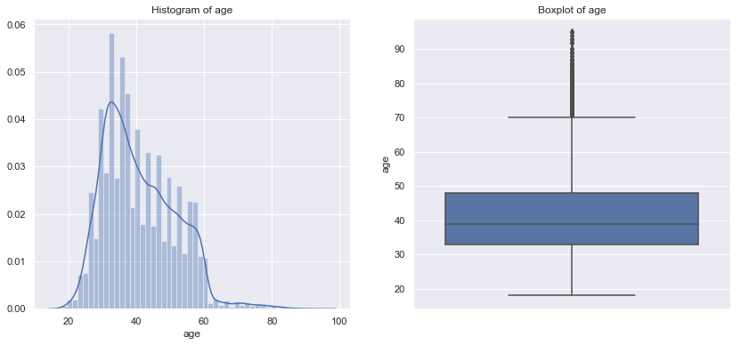

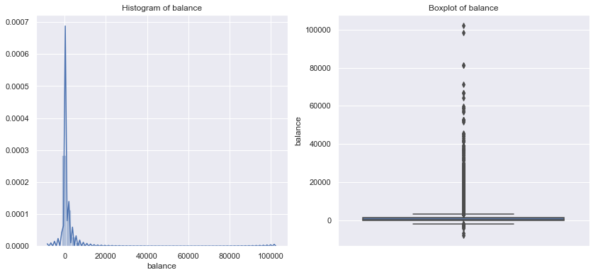

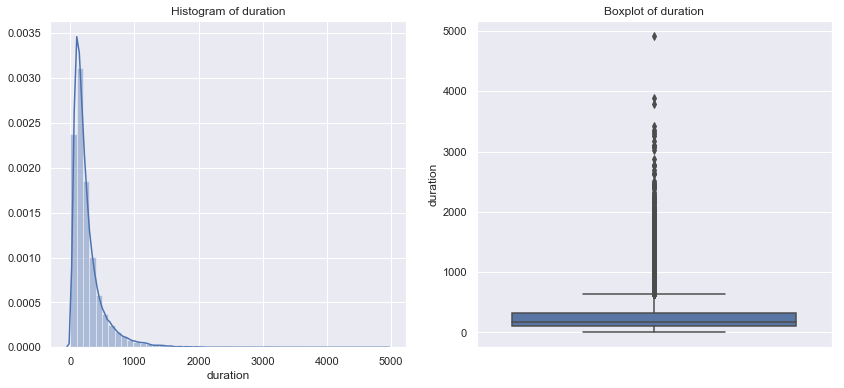

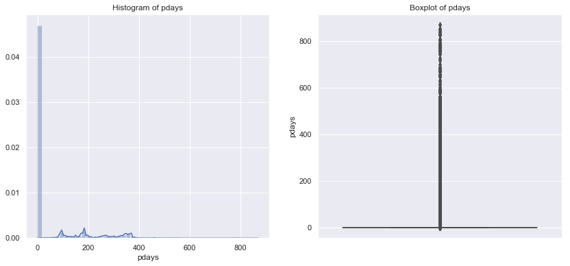

```python
for i in numerical_feature_list:
    numerical_feature_plot(i)
    numerical_feature_analysis(i)
```

Observations:  
age: Though its not perfect, data is near to normal distribution. Also the difference between mean and median is very less.  
Data tends to deviate from normal distribution after 2nd quantile and is distributed widely in this region.  
balance: Data is right skewed. And by above outlier analysis, its clear that many outliers are present in high balance.  
duration: Data is right skewed. And by above outlier analysis, its clear that many outliers are present in high duration.  
pdays: Here more than 75% of data has value -1. This feature can not be a negative value. And also, in the attribute information it was mentioned that "999 means client was not previously contacted". But value of 999 is not present in data. Since we can not contact anyone to know more on this data, assuming that there is a typo in the attribute information and considering "-1 means client was not previously contacted". So by this, it indicates that 75% of customers are not contacted in previous campaign.

```python
# Function for creating count plot and the corresponding percentage distribution plots for categorical variables
# Count plot is to help in understanding the distribution of the feature
# % distribution plot helps us to see the % distribution of different categories for a feature.
def categorical_feature_plot(feature):
    fig,ax=plt.subplots(nrows=1,ncols=2,figsize=(14,6))
    df[feature].value_counts().plot(kind='bar',ax=ax[0],rot=90,title="Counts of "+feature)
    ax[0].set_xlabel(feature)
    #sns.countplot(df[feature],ax=ax[0],order=df[feature].unique())
    #ax[0].set_title("Counts of "+feature)
    #ax[0].set_xticklabels(df[feature].unique(), rotation=90)
    df[feature].value_counts(normalize=True).plot(kind='bar',ax=ax[1])
    ax[1].set_title("Distribution of "+feature)
    ax[1].set_xlabel(feature)
    ax[1].set_ylabel("% Distribution")
    ax[1].set_xticklabels(df[feature].value_counts(normalize=True).index, rotation=90)
```

```
Distribution for feature: job

blue-collar      0.215257
management       0.209197
technician       0.168034
admin.           0.114375
services         0.091880
retired          0.050076
self-employed    0.034925
entrepreneur     0.032890
unemployed       0.028820
housemaid        0.027427
student          0.020747
unknown          0.006370
Name: job, dtype: float64
------------------------------------------
Distribution for feature: marital

married     0.601933
single      0.282896
divorced    0.115171
Name: marital, dtype: float64
------------------------------------------
Distribution for feature: education

secondary    0.513194
tertiary     0.294198
primary      0.151534
unknown      0.041074
Name: education, dtype: float64
------------------------------------------
Distribution for feature: default

no     0.981973
yes    0.018027
Name: default, dtype: float64
------------------------------------------
Distribution for feature: housing

yes    0.555838
```

[output cut: 103 more lines]

```
------------------------------------------
Distribution for feature: poutcome

unknown    0.817478
failure    0.108403
other      0.040698
success    0.033421
Name: poutcome, dtype: float64
------------------------------------------
Distribution for feature: Target

no     0.883015
yes    0.116985
Name: Target, dtype: float64
------------------------------------------
```

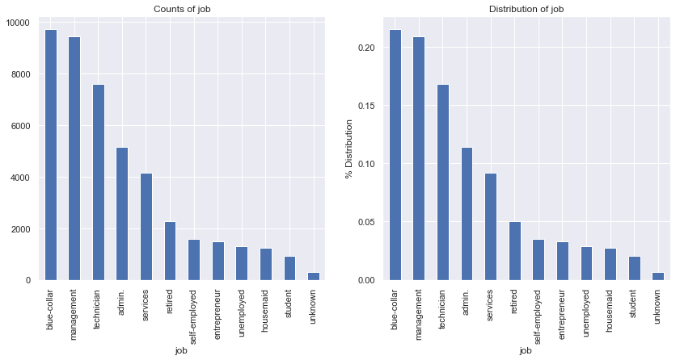

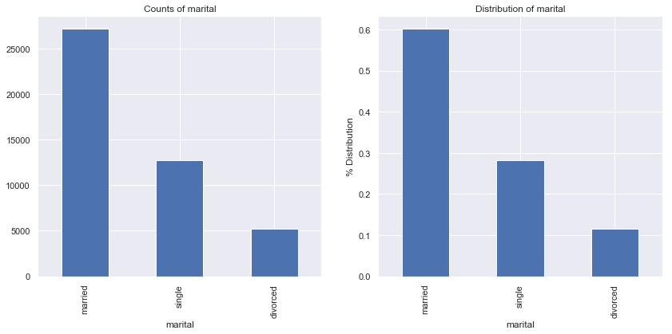

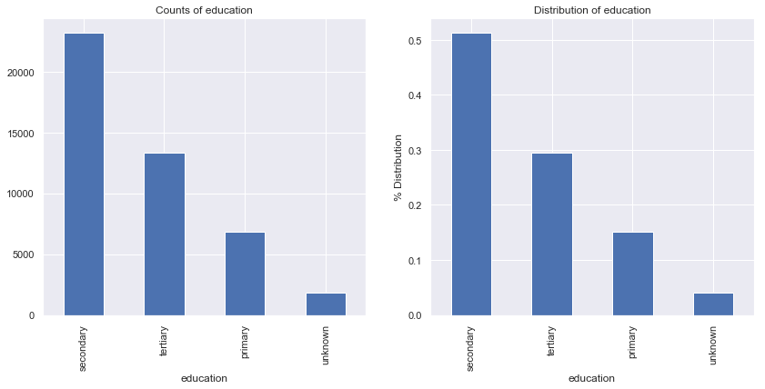

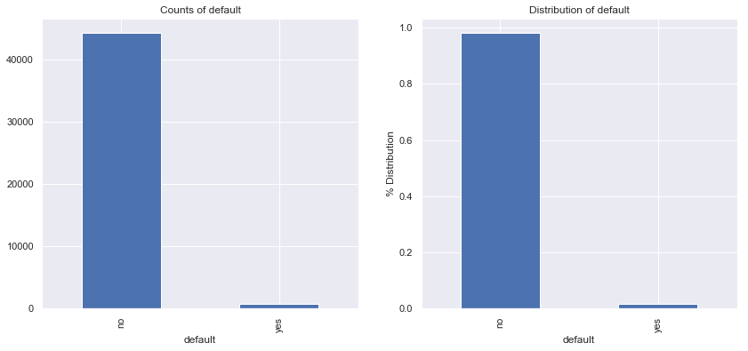

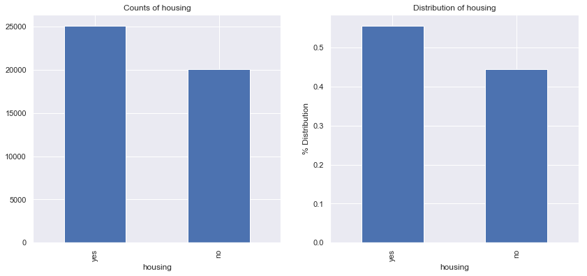

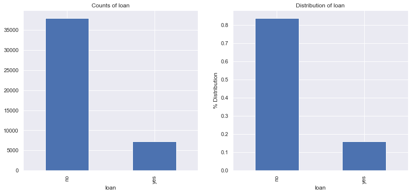

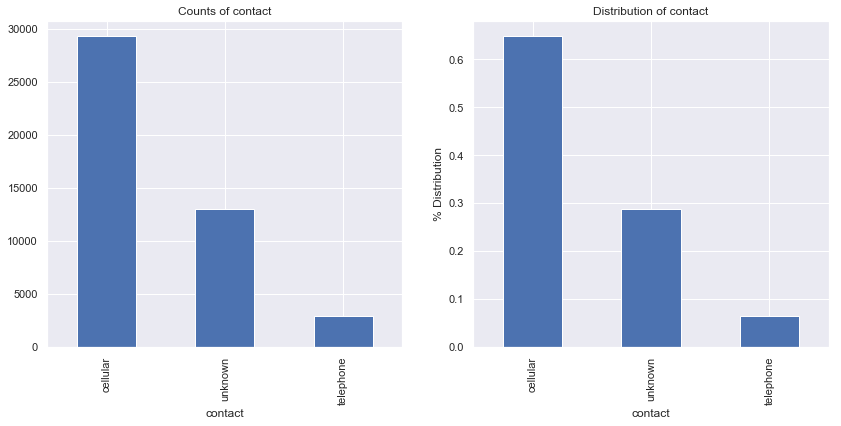

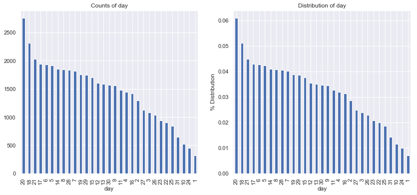

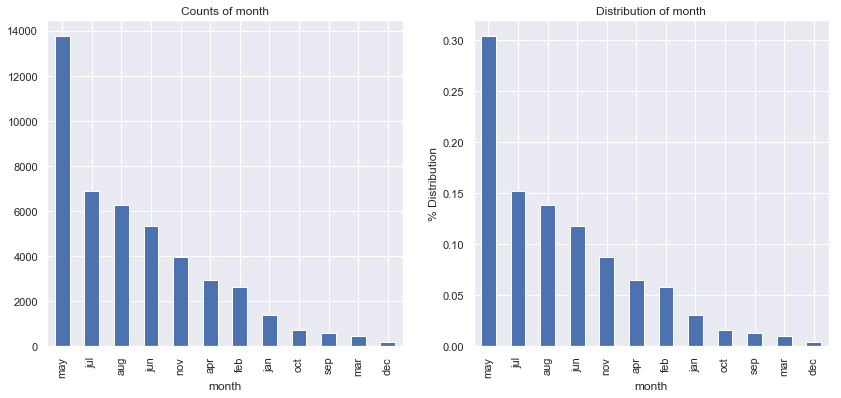

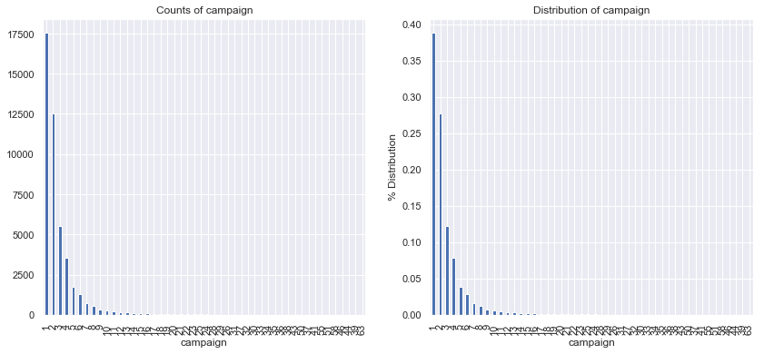

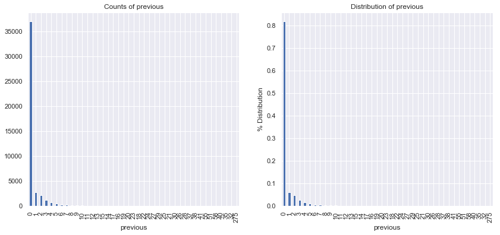

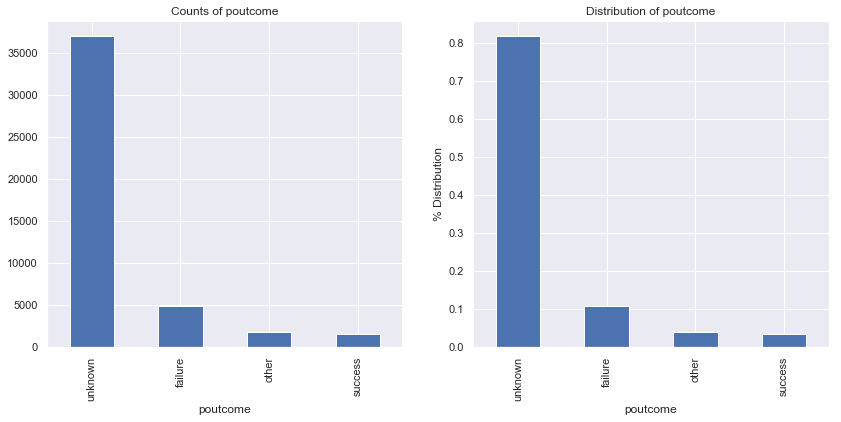

[1 more figures not shown]

```python
# Plotting for all categorical features
for i in categorical_feature_list:
    categorical_feature_plot(i)
    print("Distribution for feature: "+i+"\n")
    print(df[i].value_counts(normalize=True).head(20))
    print("------------------------------------------")
```

Observations:

job: Data is not uniformly distributed across jobs. 20+ % each of customers belong to blue-collar and management.

marital: 60% of the customers are married followed by single and divorced.

education: More than 50% of the customers have completed secondary education.

default: Most of the customer have credit default as NO. This feature may not be of useful in prediction models as the variance is very low.

housing: Good distribution is there between for this feature. 55% has housing loan and 45% didn't.

loan: 16% has taken personal loan and rest didnt have.

contact: Most of the customers are contacted through cellular (64%). Through telephone its only 6.4% and rest[29%] of the customer contact is Unknown.

campaign: 75% of data lies within value 3. Right Skewed.

previous: More than 80% of the data has value 0. This indicates that most of the customers are not contacted before this campaign and is in align with our assumption on pdays feature.

poutcome: Outcome is Unknown for 82% of the data. 11% of data is failure and only 3.3% of data is success. Since for most of the data Outcome is Unknown, in real life this feature may not be useful.

Target: 88% of the customers didnt take Term Deposit. Only 12% have opted for TD. Here also distribution is not good enough to get better predictions for customers who will opt for Term Deposit.

#### Multivariate Analysis:

```python
# Before starting analyis, its better to encode Target feature from YES/NO to 1/0
# This would help in doing the analysis better.

df['Target']=df['Target'].map({'yes':1,'no':0})
```

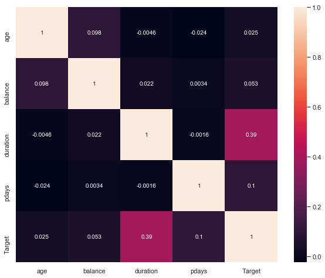

```python
# For continuous variables, Correlation with Heatmap serves as starting point
plt.figure(figsize=(10,8))
sns.heatmap(df.corr(),annot=True)
```

```python
def feature_target_plot(feature):
    #plt.figure(figsize=(12,12))
    nbins=df[feature]
    if feature in numerical_feature_list:
        g=sns.FacetGrid(data=df,col='Target',height=5, aspect =1.5)
        g.map(plt.hist,feature)
        g.set_xticklabels(rotation=90)
    else:
        g=sns.FacetGrid(data=df,col='Target',height=5, aspect =1.5)
        g.map(sns.countplot,feature,order=np.sort(df[feature].unique()))
        g.set_xticklabels(rotation=90)
```

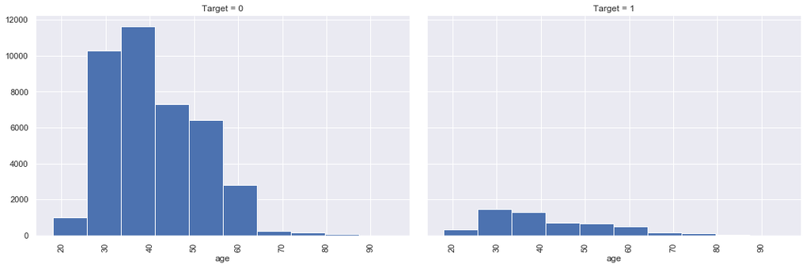

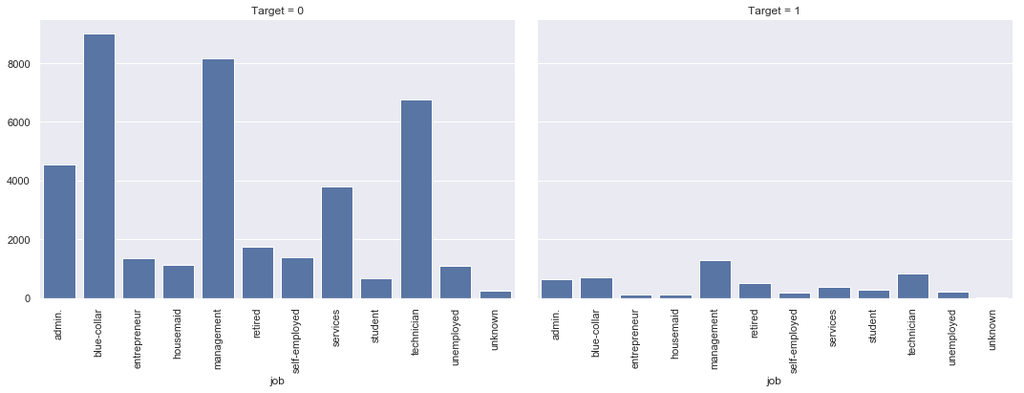

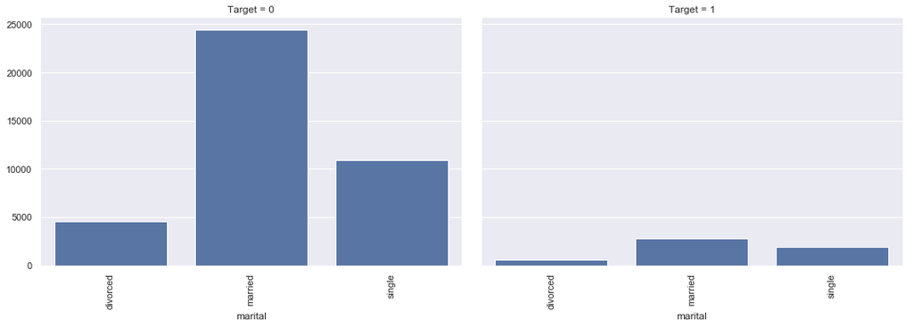

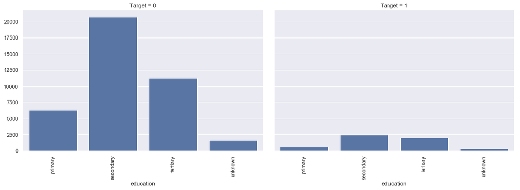

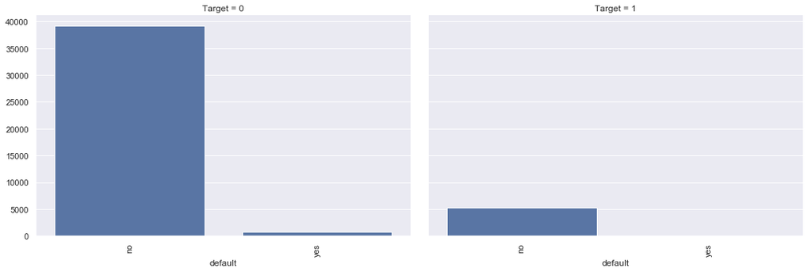

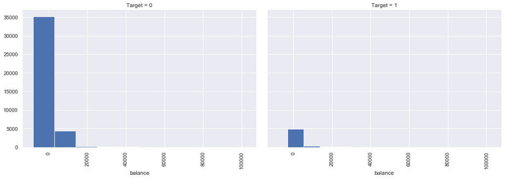

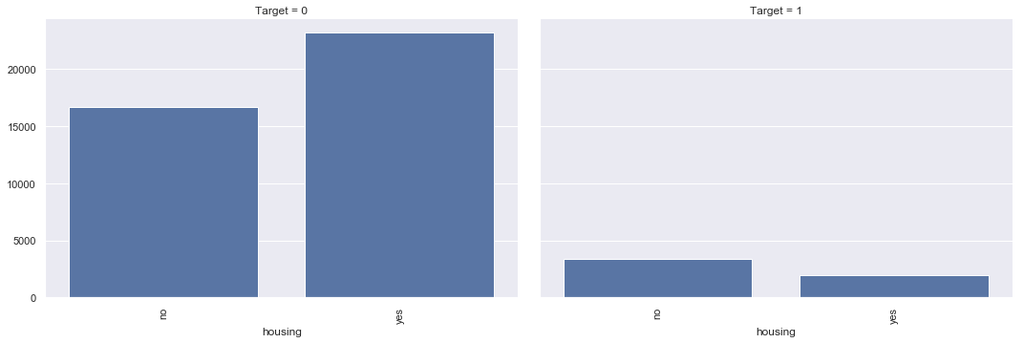

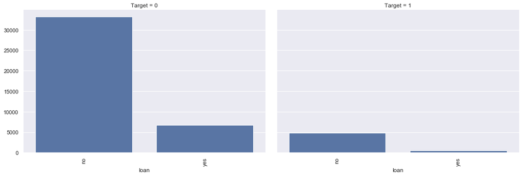

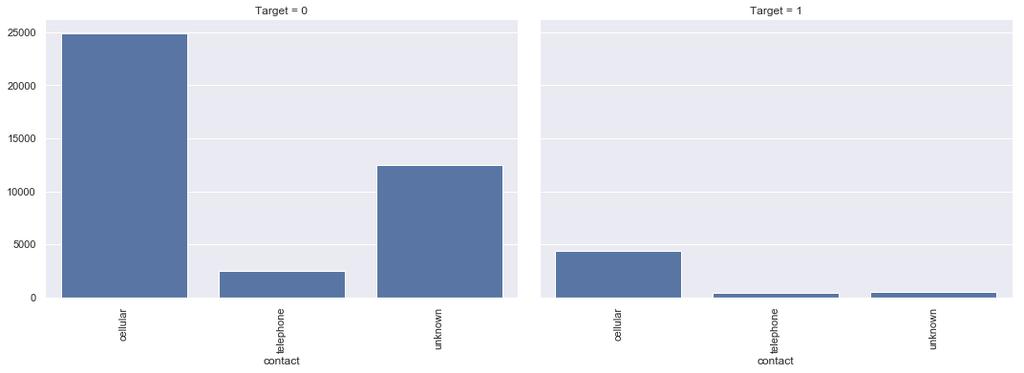

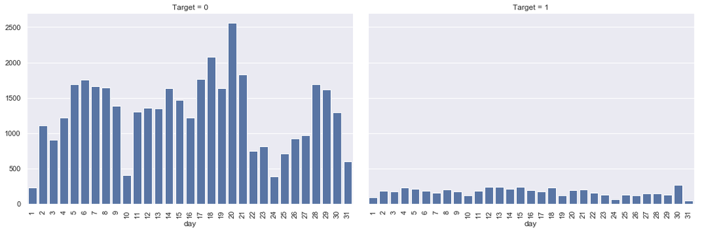

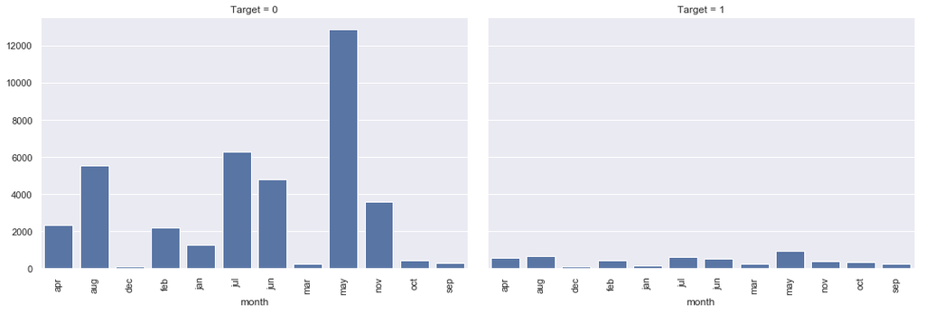

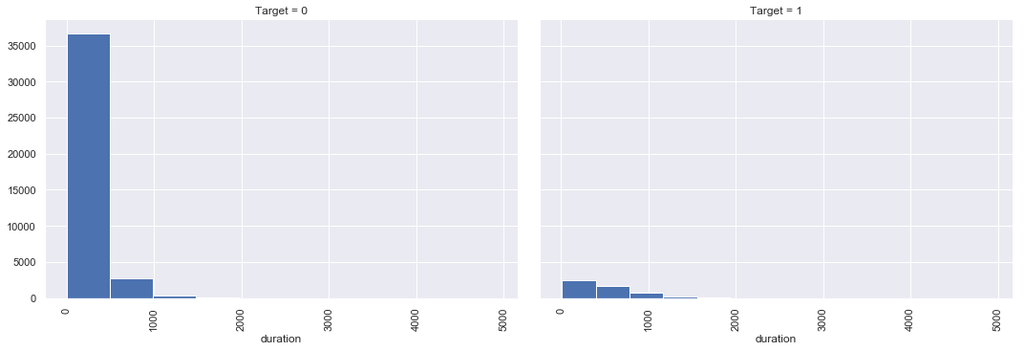

[4 more figures not shown]

```python
for i in df.columns:
    if i!='Target':
        feature_target_plot(i)
```